# Data Preparation and Manipulation

Muhammad Hilmi Abdul Majid

## Introduction

We have briefly introduced R in the previous topic. Now, we will start using R to perform data analysis and visualization. But before all that, we have to know first how to prepare and manipulate data including importing data, selecting variable from data, and so on. This topic touches on that, where we will talk about using data frames in R and data manipulation using a very useful package called `dplyr`.

## Data Frames in Base R

A data frame is a table or a two-dimensional array-like structure in which each column contains values of one variable and each row contains one set of values from each column. For example, we might have a data for students’ performance as shown below.

```
##     Names Assignment_mark Test_mark
## 1  Esther              19        45
## 2    Ruby              18        43
## 3   Gehad              15        51
## 4    Jack              10        27
## 5 Michael              17        42
## 6    Rose              16        57
```

We can see that data frame looks like a table, with rows and columns. Here we have three columns, `Names`, `Assignment_mark`, and `Test_mark`. The rows represent each student or each observation.

### Creating data frame

To create data frame, we can use the `data.frame()` function.

```r
x <- 1:10
y <- x^2
dat <- data.frame(col1=x, col2=y) # Create data frame using x and y
dat                               # Print out the data frame
```

```
##    col1 col2
## 1     1    1
## 2     2    4
## 3     3    9
## 4     4   16
## 5     5   25
## 6     6   36
## 7     7   49
## 8     8   64
## 9     9   81
## 10   10  100
```

In the example above when we write down `data.frame(col1=x, col2=y)`, what it will do is it will create a data frame, and this data frame has two columns, `col1` and `col2`, and the values for `col1` is `x`, whereas the values for `col2` is `y`. `col1` and `col2` are the column names for the data frame.

### Pulling out contents of a data frame

Then to pull out a variable of a data frame, we can use the `$` notation by writing down the data frame name, followed by `$`, and the column name. For example,

```r
x <- 1:10
y <- x^2
dat <- data.frame(col1=x, col2=y)
dat$col1     # Call out 'col1' from 'dat'
```

```
##  [1]  1  2  3  4  5  6  7  8  9 10
```

```r
dat$col2     # Call out 'col2' from 'dat'
```

```
##  [1]   1   4   9  16  25  36  49  64  81 100
```

You can also use the `[]` notation to pull out contents from a data frame. For example, `data_frame[i,j]` will pull out data at the $i$th row and $j$th column. If you want to pull out all columns of a row or all rows of a column, you can use `data_frame[i,]` and `data_frame[,j]` respectively.

```r
dat[6,2] # Pull out value at the sixth row, second column
```

```
## [1] 36
```

```r
dat[,2]  # Pull out values at all rows, second column
```

```
##  [1]   1   4   9  16  25  36  49  64  81 100
```

```r
dat[5,]  # Pull out values at fifth row, all column
```

```
##   col1 col2
## 5    5   25
```

### Some functions for data frame

The `str()` function (short for structure) can be used to quickly look into the structure of an object, including a data frame. It will give the number of observations, as well as the variable names and classes.

```r
str(dat)      # Check the structure of the data frame/object
```

```
## 'data.frame':    10 obs. of  2 variables:
##  $ col1: int  1 2 3 4 5 6 7 8 9 10
##  $ col2: num  1 4 9 16 25 36 49 64 81 100
```

From the output, we can see how many observations there are in the data frame and the number of variables. We can also see the type of values for each column or variable, and the first few values of each column.

The `name()` function can be used to list down all variable (or column) names in a data frame. It can also be used to modify the column names

```r
names(dat)                 # Print out the column names
```

```
## [1] "col1" "col2"
```

```r
names(dat) <- c("x","y")   # Change the column names to x and y
names(dat)                 # Print out the new column names
```

```
## [1] "x" "y"
```

You can also use `colnames()` to get the column names, and `rownames()` to get the row names of a data frame. Just like `names()` function, you can also modify the column or row names using `colnames()` and `rownames()`.

```r
colnames(dat)              # Print out column names
```

```
## [1] "x" "y"
```

```r
rownames(dat)              # Print out row names
```

```
##  [1] "1"  "2"  "3"  "4"  "5"  "6"  "7"  "8"  "9"  "10"
```

```r
rownames(dat)[1] <- "No.1" # Modify first row name to 'No.1'
dat                        # Print out the new data frame
```

```
##       x   y
## No.1  1   1
## 2     2   4
## 3     3   9
## 4     4  16
## 5     5  25
## 6     6  36
## 7     7  49
## 8     8  64
## 9     9  81
## 10   10 100
```

Sometimes you do not want to view all the data set, but only a few just to see what it looks like. You can use `head()` or `tail()` to print out the first or the last $n$ rows in the data set. The default value for $n$ is 6, but you can modify it by specifying `n=value` in the argument of the functions.

```r
head(dat)       # Print out top 6 rows
```

```
##      x  y
## No.1 1  1
## 2    2  4
## 3    3  9
## 4    4 16
## 5    5 25
## 6    6 36
```

```r
tail(dat, n=4)  # Print out bottom 4 rows
```

```
##     x   y
## 7   7  49
## 8   8  64
## 9   9  81
## 10 10 100
```

## Importing Data

If we want to, we can type down all the data manually and use the `data.frame()` to create a data frame for the data. However, for large amount of data, this is inefficient. It might be better to have the data in a separate TXT, CSV, or Excel file.

In RStudio, we can import the files using the *Files* pane. Just locate the file, click it, and choose *Import Dataset*. However, we can also read the files by using R commands.

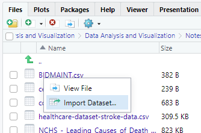

Importing data using *Files* pane in RStudio

### Reading from CSV or TXT file

To read data from a CSV or TXT file, we can use the `read.table()` function.

Here is the syntax for the function: `read.table(file_location, header, sep)`

- `file_location`: The location of the TXT or CSV file. File location uses ‘/’ or ‘\\’ and not ‘\’.
- `header`: `TRUE` if there is a header (or column name) in the file, Otherwise set it `FALSE`.
- `sep`: The separator between items in the file.

For example, if we open a CSV file with a notepad, we can see the structure of the data. From the image below, we can see that we have a header for each column, thus we need to use `header=TRUE`. We can also see that the columns are separated with a comma, hence we set `sep=","`.

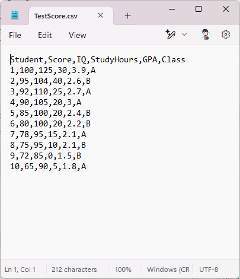

Opening a CSV file with notepad to see the structure

```r
TestScore <- read.table("D:/Data Analysis and Visualization/Notes/dataset/TestScore.csv",
                        header=TRUE, sep=",")
head(TestScore)
```

```
##   Student Score  IQ StudyHours GPA Class
## 1       1   100 125         30 3.9     A
## 2       2    95 104         40 2.6     B
## 3       3    92 110         25 2.7     A
## 4       4    90 105         20 3.0     A
## 5       5    85 100         20 2.4     B
## 6       6    80 100         20 2.2     B
```

```r
names(TestScore)
```

```
## [1] "Student"    "Score"      "IQ"         "StudyHours" "GPA"
## [6] "Class"
```

Here are some tips and tricks:

- You can choose the file interactively using `file.choose()`. For example, `TestScore <- read.table(file.choose(), header=TRUE, sep=",")`.
- For CSV file, an easier function to use is `read.csv()` as it uses the default `header=TRUE` and `sep=','`. For example, `TestScore <- read.csv(file.choose())`
- If your CSV file is large, you can use `read_csv()` function in `readr` package for faster loading time.

### Reading from Excel file

Reading from Excel file (.xls or .xlsx) requires using external libraries, for example, the `readxl` package.

```r
install.packages("readxl")   # Run once per R version to download package
library(readxl)              # Run once per session to load package
oxygen <- read_excel("D:/Data Analysis and Visualization/Notes/dataset/oxygen.xlsx")
head(oxygen)
```

```
## # A tibble: 6 × 3
##     Obs     x     y
##   <dbl> <dbl> <dbl>
## 1     1  0.99  90.0
## 2     2  1.02  89.0
## 3     3  1.15  91.4
## 4     4  1.29  93.7
## 5     5  1.46  96.7
## 6     6  1.36  94.4
```

Note that if you use `read_excel()` function, it will load the data as *tibble data frame*. As shown in the code above, there are some additional lines regarding tibble shown in the output. Tibble is simply an enhanced form of data frame. We can ignore the tibble wording in the output and use them as similar to data frame as before.

### Databases

If you have files from a database (SQL, Oracle, or others), you will need to use additional packages for example `RODBC`, `RMySQL`, `ROracle`, `RPostreSQL`, `RSQLite`, or `RMongo`. There is also the options to connect to databases using the *Connections* pane in the RStudio (see https://solutions.posit.co/connections/db/tooling/connections/)

## Exporting CSV File from R

To save a data frame into a CSV file, use `write.csv()` function. If the data frame is too large, you can also use `write_csv()` function from the `readr` package. Note that if you do not specify the file location, the CSV file will be saved in the current working directory.

```r
write.csv(TestScore, file="Created_CSV.csv", row.names=FALSE)
```

## Data Manipulation using `dplyr` Package

The `dplyr` package (which is a part of `tidyverse` package) is a popular tool used by most R users to manipulate data. You can use it to do many things including selecting data, filtering data, summarizing data, grouping data and so on.

Some functions in `dplyr` package

| Function Name | Description |
| --- | --- |
| `select` | Select variables or columns |
| `filter` | Select observations or rows |
| `mutate` | Transforming variables |
| `summarize` | Summarize data by a function |
| `group_by` | Group data |

To install the `dplyr` package, simply run `install.packages("dplyr")` to download the file for the current R version used. Then, to load the downloaded files, use `library(dplyr)`.

We will go through with examples on using these functions using the `starwars` dataset in `dplyr` package. The data list all the characters in the Star Wars movies including their names, heights, weights, species and so on. You can run `?dplyr::starwars` or `help(dplyr::starwars)` to read the description of the data and its variables.

### Selecting variables with `select`

```r
# Install the dplyr package
install.packages("dplyr")

# Load the dplyr package
library(dplyr)
```

```r
# Print 5 rows of the original starwars dataset
head(starwars, n=5)
```

```
## # A tibble: 5 × 14
##   name      height  mass hair_color skin_color eye_color birth_year sex   gender
##   <chr>      <int> <dbl> <chr>      <chr>      <chr>          <dbl> <chr> <chr>
## 1 Luke Sky…    172    77 blond      fair       blue            19   male  mascu…
## 2 C-3PO        167    75 <NA>       gold       yellow         112   none  mascu…
## 3 R2-D2         96    32 <NA>       white, bl… red             33   none  mascu…
## 4 Darth Va…    202   136 none       white      yellow          41.9 male  mascu…
## 5 Leia Org…    150    49 brown      light      brown           19   fema… femin…
## # ℹ 5 more variables: homeworld <chr>, species <chr>, films <list>,
## #   vehicles <list>, starships <list>
```

To use the `select()` function, simply use the data set as the first argument, followed by the columns that we want to select in the following arguments.

```r
# Select only the variables name, height, and mass from the data
data <- select(starwars, name, height, mass)
head(data, n=5)
```

```
## # A tibble: 5 × 3
##   name           height  mass
##   <chr>           <int> <dbl>
## 1 Luke Skywalker    172    77
## 2 C-3PO             167    75
## 3 R2-D2              96    32
## 4 Darth Vader       202   136
## 5 Leia Organa       150    49
```

Alternatively, you can remove columns using the `-` sign followed by the column name.

```r
# Keep all variables except name, height, and mass from the data
data <- select(starwars, -name, -height, -mass)
head(data, n=5)
```

```
## # A tibble: 5 × 11
##   hair_color skin_color  eye_color birth_year sex    gender    homeworld species
##   <chr>      <chr>       <chr>          <dbl> <chr>  <chr>     <chr>     <chr>
## 1 blond      fair        blue            19   male   masculine Tatooine  Human
## 2 <NA>       gold        yellow         112   none   masculine Tatooine  Droid
## 3 <NA>       white, blue red             33   none   masculine Naboo     Droid
## 4 none       white       yellow          41.9 male   masculine Tatooine  Human
## 5 brown      light       brown           19   female feminine  Alderaan  Human
## # ℹ 3 more variables: films <list>, vehicles <list>, starships <list>
```

### Selecting observations with `filter`

The `filter()` function is used to filter out observations from the data. It requires the Boolean operators (and `&`, or `|`, equals `==`, not equals `!=`) for the selection criteria.

To use the `filter()` function, simply use the data as the first argument, followed by the filtering condition as the second argument.

```r
# To save space, select some columns only from starwars dataset
starwars2 <- select(starwars, name, height, mass, sex, homeworld)

# Select males only
data <- filter(starwars2, sex == "male")
head(data, n=5)
```

```
## # A tibble: 5 × 5
##   name              height  mass sex   homeworld
##   <chr>              <int> <dbl> <chr> <chr>
## 1 Luke Skywalker       172    77 male  Tatooine
## 2 Darth Vader          202   136 male  Tatooine
## 3 Owen Lars            178   120 male  Tatooine
## 4 Biggs Darklighter    183    84 male  Tatooine
## 5 Obi-Wan Kenobi       182    77 male  Stewjon
```

```r
# Select males from Tatooine only
data <- filter(starwars2,
               sex == "male" & homeworld == "Tatooine")
head(data, n=5)
```

```
## # A tibble: 5 × 5
##   name              height  mass sex   homeworld
##   <chr>              <int> <dbl> <chr> <chr>
## 1 Luke Skywalker       172    77 male  Tatooine
## 2 Darth Vader          202   136 male  Tatooine
## 3 Owen Lars            178   120 male  Tatooine
## 4 Biggs Darklighter    183    84 male  Tatooine
## 5 Anakin Skywalker     188    84 male  Tatooine
```

### Transforming variables with `mutate`

The `mutate()` function is used to transform variables. We can use it to modify an existing column, or create new columns in the data. To use it, use the data as the first argument, followed by the name of the existing/new column that we want to modify and how the values of the column are calculated.

```r
# Check the name and height for the first row of original data
select(starwars2, name, height)[1,]
```

```
## # A tibble: 1 × 2
##   name           height
##   <chr>           <int>
## 1 Luke Skywalker    172
```

```r
# Transform height from cm to inches
data <- mutate(starwars2, height=height*0.394)

# Check the name and height for the first row of modified data
select(data, name, height)[1,]
```

```
## # A tibble: 1 × 2
##   name           height
##   <chr>           <dbl>
## 1 Luke Skywalker   67.8
```

In the code above we used the existing column `height` and replace it with another calculation. If you want to use mutate to create a new variable in the data, simply use another unused column name.

```r
# Create a new column height_in
data <- mutate(starwars2, height_in=height*0.394)

# Check available columns in new data
names(data)
```

```
## [1] "name"      "height"    "mass"      "sex"       "homeworld" "height_in"
```

Additionally, you can use the `ifelse()` function to encode the variable. The syntax for the function is `ifelse(<condition>, <return if TRUE>, <return if FALSE>)`.

```r
# Create a new variable 'height_category'
# If height is more than 180, the category is tall, otherwise it is short
data <- mutate(starwars2,
               height_category = ifelse(height > 180,
                                        "tall",
                                        "short"))

# Print 5 rows for name and height_category
head(data, n=5)
```

```
## # A tibble: 5 × 6
##   name           height  mass sex    homeworld height_category
##   <chr>           <int> <dbl> <chr>  <chr>     <chr>
## 1 Luke Skywalker    172    77 male   Tatooine  short
## 2 C-3PO             167    75 none   Tatooine  short
## 3 R2-D2              96    32 none   Naboo     short
## 4 Darth Vader       202   136 male   Tatooine  tall
## 5 Leia Organa       150    49 female Alderaan  short
```

### Summarizing data with `summarize`

The `summarize()` or `summarise()` function is used to summarize the data into a single value, for example the average or the mean. It is often used together with the `group_by()` function, which groups the data into selected categories. In the code below, `na.rm=TRUE` argument is used to remove NA values when calculating mean.

To use it, simply use the data as the first argument, followed by the name of the summarization value and how to calculate them.

```r
# Calculate mean height and mean mass
data <- summarize(starwars,
                  mean_height = mean(height, na.rm=TRUE),
                  mean_mass = mean(mass, na.rm=TRUE))
data
```

```
## # A tibble: 1 × 2
##   mean_height mean_mass
##         <dbl>     <dbl>
## 1        175.      97.3
```

When used with `group_by()` function, the summarization will only apply to each individual group.

```r
# Group the observations by sex
data <- group_by(starwars, sex)

# Calculate mean height and mean mass by sex
data <- summarize(data,
                  mean_height = mean(height, na.rm=TRUE),
                  mean_mass = mean(mass, na.rm=TRUE))
data
```

```
## # A tibble: 5 × 3
##   sex            mean_height mean_mass
##   <chr>                <dbl>     <dbl>
## 1 female                172.      54.7
## 2 hermaphroditic        175     1358
## 3 male                  179.      80.2
## 4 none                  131.      69.8
## 5 <NA>                  175       81
```

### Pipes in `dplyr`

The `dplyr` package allows us to use a different way for writing codes, by using the pipe `%>%` or `|>` operator. Using this operator replaces the first argument of a function by the value. For example `x %>% fn()` is the same as `fn(x)`.

The pipe operator is useful if we want to manipulate a data frame using a combination of multiple functions. It makes the data manipulation process easier to read and write. In the example below, we start with the `starwars` data set, then group it by `sex`, and perform calculations to summarize the data.

```r
# Similar code before but using pipes
data <- starwars %>%
  group_by(sex) %>%
  summarize(mean_height = mean(height, na.rm=TRUE),
            mean_mass = mean(mass, na.rm=TRUE))
data
```

```
## # A tibble: 5 × 3
##   sex            mean_height mean_mass
##   <chr>                <dbl>     <dbl>
## 1 female                172.      54.7
## 2 hermaphroditic        175     1358
## 3 male                  179.      80.2
## 4 none                  131.      69.8
## 5 <NA>                  175       81
```

## Other Useful Data Manipulation Techniques

### Converting text to date

Often time, data are stored as text although it should be treated as dates. To convert text data (written in date format) to date data, we can use `ymd()`, `dmy()`, and `mdy()` functions from the `lubridate` package. We will talk more on this when we go through future topic on time dependent variable.

```r
install.packages("lubridate")      # Run once per R version
library(lubridate)                 # Run once per session
data <- c("25/11/1820", "29-Jan-1988", "13-Jan-1999")
str(data)               # Check format of the data

new_data <- dmy(data)
new_data
str(new_data)           # Check structure and format of new data
```

```
##  chr [1:3] "25/11/1820" "29-Jan-1988" "13-Jan-1999"
```

```
## [1] "1820-11-25" "1988-01-29" "1999-01-13"
```

```
##  Date[1:3], format: "1820-11-25" "1988-01-29" "1999-01-13"
```

### Pivoting/Unpivoting table

Sometimes, we may have to modify data by pivoting or unpivoting it. Pivoting a data means to modify and transform the data from a tall/skinny format to a short/wide format, by transforming values in a column as the new column header.

Unpivoting a data is the other way around, that is to transform the data from short/wide format to tall/skinny format by taking multiple columns and combining them into one, and creating a new column for the values.

Suppose we have the table below which shows sales of two sales advisors in January, February, March and April. This is the short/wide format as the values in the month columns (Jan, Feb, Mar, Apr) refer to the same value but in different time period.

```
##   Sales_advisor Jan Feb Mar Apr
## 1          Rose 122 121  75  87
## 2         Bruno 110  56 125  67
```

We can use the `pivot_wider()` and `pivot_longer()` from the `tidyr` package to pivot or unpivot the data. For example, to unpivot the sales data, we can use the following code.

```r
install.packages("tidyr")     # Run once per R version
library(tidyr)                # Run once per session
Sales_tall <- pivot_longer(Sales,
             cols = c("Jan","Feb","Mar","Apr"), # Choose to combine these columns
             names_to = "Month",                # Name the new column
             values_to = "Amount")              # Name the value column
Sales_tall
```

```
## # A tibble: 8 × 3
##   Sales_advisor Month Amount
##   <chr>         <chr>  <dbl>
## 1 Rose          Jan      122
## 2 Rose          Feb      121
## 3 Rose          Mar       75
## 4 Rose          Apr       87
## 5 Bruno         Jan      110
## 6 Bruno         Feb       56
## 7 Bruno         Mar      125
## 8 Bruno         Apr       67
```

And to change it back to the short/wide format, we can use the following code.

```r
Sales_short <- pivot_wider(Sales_tall,
                           names_from = "Month", # Choose the Month column to be split
                           values_from = "Amount") # Choose the Amount column as values
Sales_short
```

```
## # A tibble: 2 × 5
##   Sales_advisor   Jan   Feb   Mar   Apr
##   <chr>         <dbl> <dbl> <dbl> <dbl>
## 1 Rose            122   121    75    87
## 2 Bruno           110    56   125    67
```

In many cases, we prefer to have data in the tall/skinny format as each column refers to a variable. However, some data are collected or presented using the short/wide format.

## Conclusion

This topic discusses on how to load, prepare, and conduct data manipulation using the base R and the `dplyr` package. The process of data manipulation is important for data analysis as we require data in certain format or form to conduct the analysis. In the next topic, we will start producing data visualization using R. We will use the base R first (or R without ggplot2 package) and proceed to using ggplot2 package in the following topic.